## 1. Introduction

**Background:** Flight landing.  
**Motivation:** To reduce the risk of landing overrun.  
**Goal:** To study what factors and how they would impact the landing distance of a commercial flight.  
**Approach:** Use Logistic Regression to classify risky and safe landings  
**Data:** Landing data (landing distance and other parameters) from 950 commercial flights (not real data set but simulated from statistical models).

#### Variable dictionary

**Aircraft:** The make of an aircraft (Boeing or Airbus).  
**Duration (in minutes):** Flight duration between taking off and landing. The duration of a normal flight should always be greater than 40min.  
**No_pasg:** The number of passengers in a flight.  
**Speed_ground (in miles per hour):** The ground speed of an aircraft when passing over the threshold of the runway. If its value is less than 30MPH or greater than 140MPH, then the landing would be considered as abnormal.  
**Speed_air (in miles per hour):** The air speed of an aircraft when passing over the threshold of the runway. If its value is less than 30MPH or greater than 140MPH, then the landing would be considered as abnormal.  
**Height (in meters):** The height of an aircraft when it is passing over the threshold of the runway. The landing aircraft is required to be at least 6 meters high at the threshold of the runway.  
**Pitch (in degrees):** Pitch angle of an aircraft when it is passing over the threshold of the runway.  
**Distance (in feet):** The landing distance of an aircraft. More specifically, it refers to the distance between the threshold of the runway and the point where the aircraft can be fully stopped. The length of the airport runway is typically less than 6000 feet.

## 2. Setup

All duplicates are removed and a clean dataset is setup to work with.

```r
library(ggplot2)
library(MASS)
library(dplyr)
library(faraway)
library("nnet")
faa1 <- read.csv("C:/Users/nifaullah/Downloads/FAAc1.csv")
faa2 <- read.csv("C:/Users/nifaullah/Downloads/FAAc2.csv")
# Removing empty factor data if any
faa2 <- droplevels(subset(faa2, aircraft != ""))
# Creating the missing column duration in faa2 before merging the datasets vertically
faa2$duration <- NA
# Merging Verically
faa <- rbind(faa1, faa2)
# Selecting duplicates minus duration as durtion was not originally present in 2nd Dataset
duplicate_rows <- faa  %>%
  select(-duration) %>%
  duplicated() %>%
  which()
#Removing duplicates
faa <- faa[-duplicate_rows,]
# After removing duplicates
dim(faa)
```

```
## [1] 850   8
```

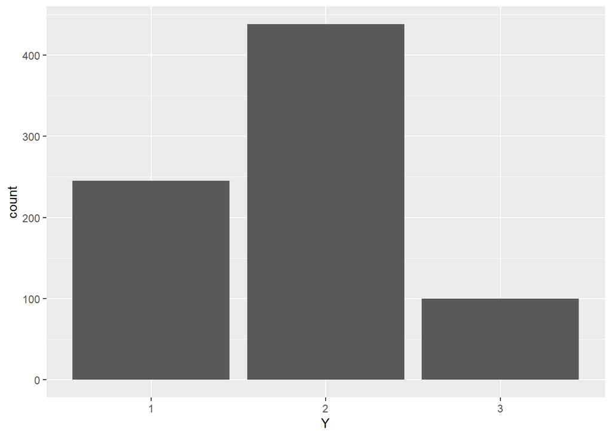

```r
# Remove all abnormal rows as per the dictionary definition
faa_normal <- faa %>%
  filter(duration >40,
         (speed_ground >=30 | speed_ground <=140),
         (is.na(speed_air) | speed_air >=30 | speed_air <=140),
         height >=6, distance < 6000)
# Creating Categorical variables for classification
faa_normal$Y <- ifelse(faa_normal$distance < 1000, 1, ifelse(faa_normal$distance < 2500, 2, 3))
faa_normal$Y <- as.factor(faa_normal$Y)
#Removing Distance Column and Speed_air column as it has high correlation with Speed_ground
faa_normal <- subset(faa_normal, select = -c(distance, speed_air))
#Histogram for Risky Landing
ggplot(faa_normal, aes(x=Y)) +
   labs(x="Y") +
    geom_bar()
```

## 3. Model Selection

First we regess the full model and then we use step function to select the best model based on AIC.

```r
full_model <- multinom(Y ~ aircraft + speed_ground + height + pitch + no_pasg+ duration, faa_normal )
step_model <- step(full_model)
```

```
## Start:  AIC=458.07
## Y ~ aircraft + speed_ground + height + pitch + no_pasg + duration
##
## trying - aircraft
## trying - speed_ground
## trying - height
## trying - pitch
## trying - no_pasg
## trying - duration
##                Df       AIC
## - no_pasg      12  455.5564
## - duration     12  455.8495
## <none>         14  458.0675
## - pitch        12  458.2671
## - height       12  569.4471
## - aircraft     12  628.5441
## - speed_ground 12 1439.7835
##
## Step:  AIC=455.56
## Y ~ aircraft + speed_ground + height + pitch + duration
##
## trying - aircraft
## trying - speed_ground
## trying - height
## trying - pitch
## trying - duration
##                Df       AIC
## - duration     10  453.3108
## <none>         12  455.5564
## - pitch        10  455.7267
## - height       10  566.7456
## - aircraft     10  625.9150
## - speed_ground 10 1436.1834
##
## Step:  AIC=453.31
## Y ~ aircraft + speed_ground + height + pitch
##
## trying - aircraft
## trying - speed_ground
## trying - height
## trying - pitch
##                Df       AIC
## <none>         10  453.3108
## - pitch         8  453.6693
## - height        8  566.0935
## - aircraft      8  624.1436
## - speed_ground  8 1437.3326
```

```r
summary(step_model)
```

```
## Call:
## multinom(formula = Y ~ aircraft + speed_ground + height + pitch,
##     data = faa_normal)
##
## Coefficients:
##   (Intercept) aircraftboeing speed_ground    height      pitch
## 2   -19.41428       3.723276    0.2167328 0.1390243 -0.3293647
## 3  -132.77008       8.645437    1.1895559 0.3810112  1.0100623
##
## Std. Errors:
##   (Intercept) aircraftboeing speed_ground     height     pitch
## 2  1.88154920      0.3975984   0.01765206 0.01703552 0.2659644
## 3  0.03364901      0.8568989   0.02846458 0.04038931 0.7434756
##
## Residual Deviance: 433.3108
## AIC: 453.3108
```

```r
### Difference between deviances
deviance(step_model)-deviance(full_model)
```

```
## [1] 3.243309
```

```r
### Difference between degrees of freedom
full_model$edf-step_model$edf
```

```
## [1] 4
```

```r
### Chi^2 test
pchisq(deviance(step_model)-deviance(full_model),full_model$edf-step_model$edf,lower=F)
```

```
## [1] 0.5179643
```

## 4. Plots & Inferences

Comparatively Boieng dominates category 2 and 3 but Airbus dominates Category 1.

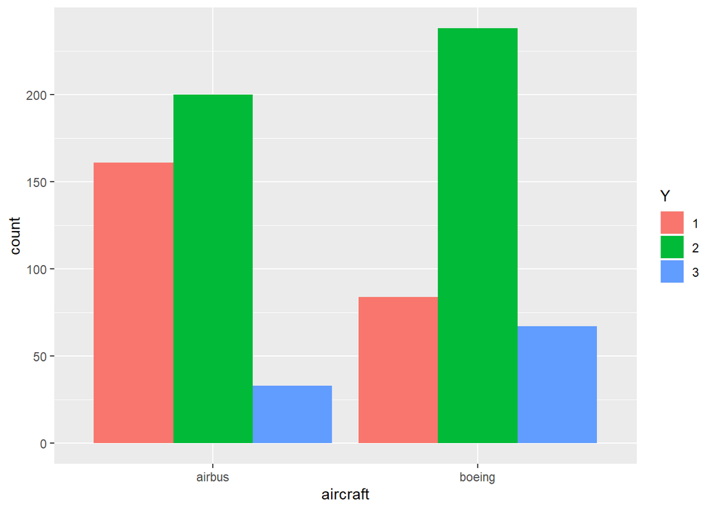

```r
ggplot(faa_normal, aes(x=aircraft, fill=Y)) +
  geom_bar(position = 'dodge')
```

There seems to be a positive correlation between Speed_Ground & the categorical variable Y.

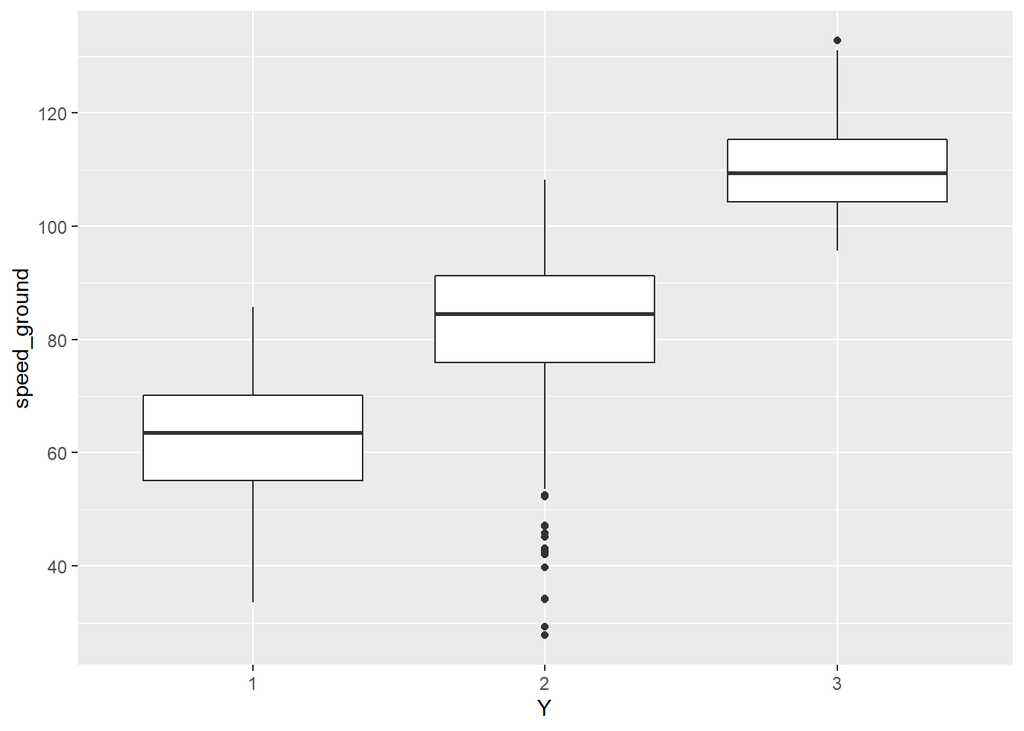

```r
ggplot(faa_normal, aes(x=Y, y=speed_ground)) +
  geom_boxplot()
```

The range of height for Category 1 is lesser than Category 3 which is slightly lesser than category 2.

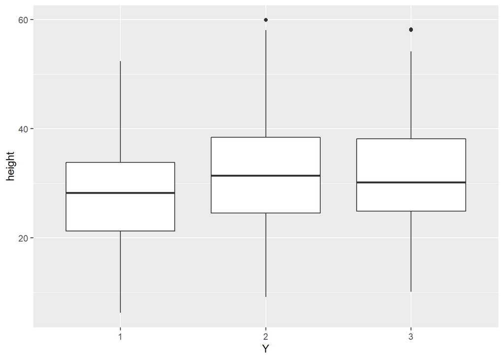

```r
ggplot(faa_normal, aes(x=Y, y=height)) +
  geom_boxplot()
```

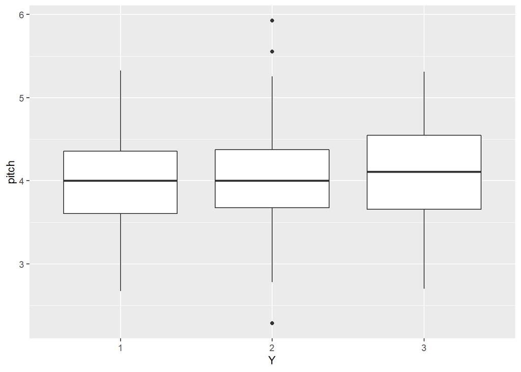

```r
ggplot(faa_normal, aes(x=Y, y=pitch)) +
  geom_boxplot()
```